# Ligand Activity Regressions: Thomas IBD

EYW

2026-08-17

```r
knitr::opts_chunk$set(echo = TRUE)
source("regression_helpers.R")
```

# Goal

Test which SIG13 ligand activities differ in colonic CD4 T cells in UC and CD (Thomas et al. 2024), using the activity scores from `02_score_disease_datasets.py`.

Model families, each fit across all conventional CD4 T cells and per celltype:

1. **Disease** (pre-treatment only) – UC / CD / Healthy, pairwise
2. **Disease x remission** (pre-treatment) – does baseline activity predict who later goes into remission?
3. **Vs healthy** – every disease x remission x timepoint group against healthy
4. **Post vs pre treatment** – within each disease x remission group
5. **Celltype** – which activities distinguish CD4 subsets

All models adjust for sex and biopsy site and use HC3 robust covariance (patient numbers per group are uneven). Age is deliberately *not* a covariate: the healthy donors are much older than every patient group, so age is collinear with disease.

# Import

```r
IBD_KEYS <- c("Disease", "Patient", "Gender", "Remission_status", "Site",
              "Inflammation", "Treatment")

# The healthy donors carry placeholder metadata: no remission status and no
# timepoint (stored as the string "nan"). Renaming the timepoint to "None" gives
# the clean reference group label "Healthy_None_None" -- the old analysis used
# "Healthy_None _nan", the stray space coming from a trailing space in
# Remission_status that step 02 now strips at the source.
prepare_ibd <- function(df) {
  df %>%
    mutate(Treatment = ifelse(Treatment == "nan", "None", Treatment),
           disease_remission = paste(Disease, Remission_status, sep = "_"),
           disease_remission_treatment = paste(Disease, Remission_status, Treatment, sep = "_"),
           patient_site = paste(Patient, Site, sep = "_"),
           sex = factor(Gender),
           site = factor(Site),
           Disease = factor(Disease, c("UC", "CD", "Healthy")),
           Treatment = factor(Treatment, c("Pre", "Post", "None")))
}

ibd <- load_activity_scores("thomas_ibd", IBD_KEYS) %>% prepare_ibd()
ibd_celltype <- load_activity_scores("thomas_ibd_celltype", c(IBD_KEYS, "final_analysis")) %>%
  rename(celltype = final_analysis) %>%
  prepare_ibd() %>%
  mutate(celltype = fct_relevel(factor(celltype), "CD4 naive T"))

activities <- activity_names()
cat(nrow(ibd), "samples,", length(activities), "ligand activities\n")
```

```
## 216 samples, 38 ligand activities
```

```r
count(ibd, Disease, Remission_status, Treatment)
```

```
## # A tibble: 10 × 4
##    Disease Remission_status Treatment     n
##    <fct>   <chr>            <fct>     <int>
##  1 UC      Non_Remission    Pre          35
##  2 UC      Non_Remission    Post         36
##  3 UC      Not_avail        Pre           4
##  4 UC      Remission        Pre          16
##  5 UC      Remission        Post         17
##  6 CD      Non_Remission    Pre          16
##  7 CD      Non_Remission    Post         12
##  8 CD      Remission        Pre          33
##  9 CD      Remission        Post         35
## 10 Healthy None             None         12
```

The Tregs are excluded from the whole-sample scores upstream (step 02), so `ibd` is conventional CD4 T cells only; `ibd_celltype` retains every subset.

# Covariate QC

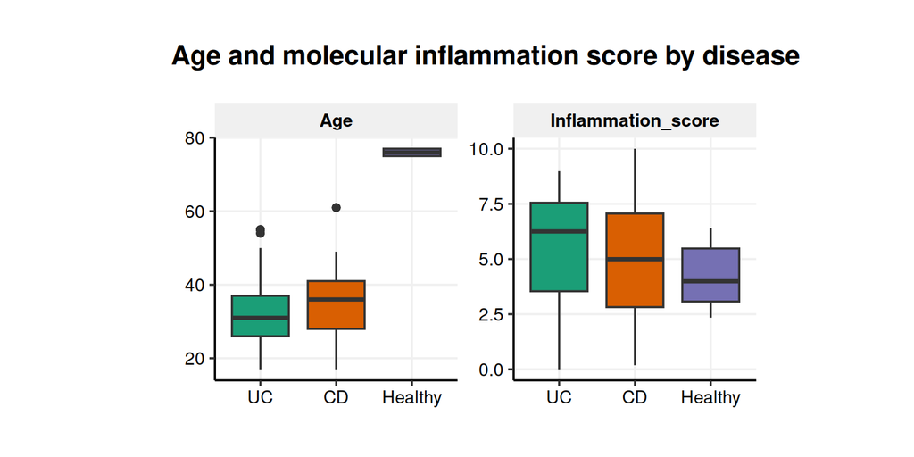

```r
ibd %>%
  pivot_longer(c(Age, Inflammation_score), names_to = "variable", values_to = "value") %>%
  ggplot(aes(x = Disease, y = value, fill = Disease)) +
  geom_boxplot(show.legend = FALSE, na.rm = TRUE) +
  scale_fill_brewer(palette = "Dark2") +
  facet_wrap(~variable, scales = "free_y") +
  theme(aspect.ratio = 1) +
  labs(title = "Age and molecular inflammation score by disease", x = "", y = "")
```

Age is strongly confounded with disease (healthy donors are older than all patient groups) and `Batch` partly so (all healthy donors are Batch 3) – neither is used as a covariate.

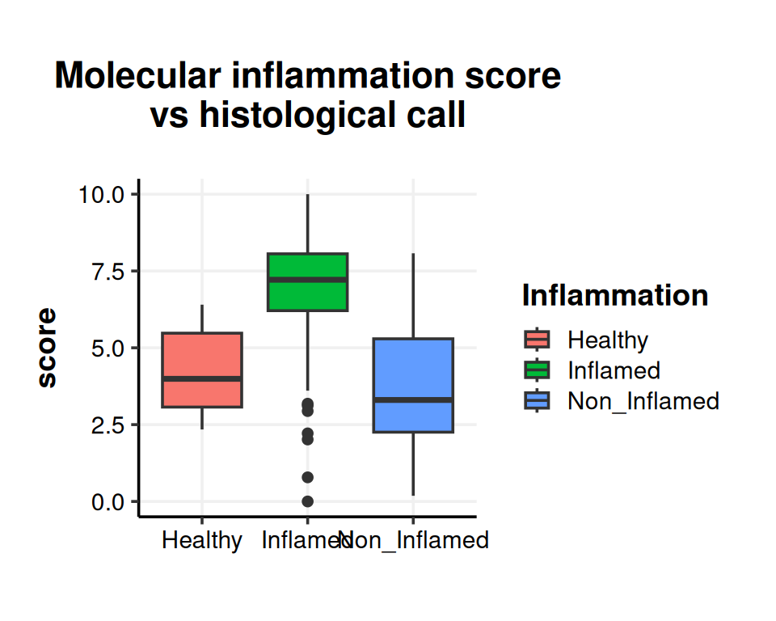

```r
ibd %>%
  ggplot(aes(x = Inflammation, y = Inflammation_score, fill = Inflammation)) +
  geom_boxplot() +
  theme(aspect.ratio = 1) +
  labs(title = "Molecular inflammation score\nvs histological call", x = "", y = "score")
```

The paper filters IBD samples to molecular inflamed (`Inflammation_score > 6.5`, just above the healthy maximum) rather than trusting the histological call. That filter is available below but, is **not** applied – every model uses all samples.

```r
baseline_uninflamed <- ibd %>%
  filter(Treatment == "Pre", Disease %in% c("UC", "CD"), Inflammation_score < 6.5) %>%
  pull(patient_site)
cat(length(baseline_uninflamed), "pre-treatment IBD samples are molecularly uninflamed",
    "(not excluded)\n")
```

```
## 47 pre-treatment IBD samples are molecularly uninflamed (not excluded)
```

# Disease associations

## Pre-treatment disease

```r
ibd_pre <- filter(ibd, Treatment %in% c("Pre", "None"))

res_disease <- fit_and_save(
  ibd_pre,
  rhs = "Disease + sex + site",
  emm = ~ Disease,
  contrast_args = list(method = "pairwise"),
  robust = TRUE,
  name = "thomas_ibd_disease_pre"
)
```

```
## thomas_ibd_disease_pre: 114 contrast x activity rows, 35 with padj < 0.1
```

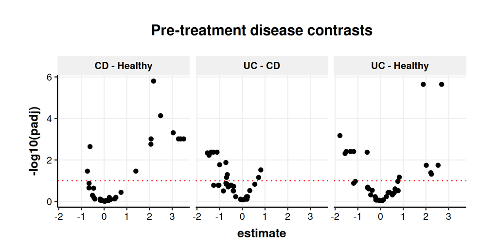

```r
res_disease %>%
  ggplot(aes(x = estimate, y = -log10(padj))) +
  geom_point() +
  geom_hline(yintercept = 1, linetype = "dotted", color = "red") +
  facet_wrap(~contrast) +
  theme(aspect.ratio = 1) +
  labs(title = "Pre-treatment disease contrasts")
```

## Pre-treatment disease x remission

```r
res_disease_remission <- fit_and_save(
  ibd_pre %>%
    mutate(disease_remission = factor(disease_remission,
                                      c("UC_Remission", "UC_Non_Remission",
                                        "CD_Remission", "CD_Non_Remission",
                                        "Healthy_None"))),
  rhs = "disease_remission + sex + site",
  emm = ~ disease_remission,
  contrast_args = list(method = "pairwise"),
  robust = TRUE,
  name = "thomas_ibd_disease_remission_pre"
)
```

```
## thomas_ibd_disease_remission_pre: 380 contrast x activity rows, 73 with padj < 0.1
```

## Every group vs healthy

```r
# healthy donors have no remission status or timepoint, so they are the single
# reference group; UC patients with unknown remission status are dropped
ibd_vs_healthy <- ibd %>%
  filter(Treatment %in% c("Pre", "Post") | Disease == "Healthy") %>%
  filter(Remission_status != "Not_avail" | Disease == "Healthy") %>%
  mutate(disease_remission_treatment = factor(disease_remission_treatment))

res_vs_healthy <- fit_and_save(
  ibd_vs_healthy,
  rhs = "disease_remission_treatment + sex + site",
  emm = ~ disease_remission_treatment,
  contrast_args = list(method = "trt.vs.ctrl", ref = "Healthy_None_None"),
  robust = TRUE,
  name = "thomas_ibd_disease_treatment_vsHealthy"
)
```

```
## thomas_ibd_disease_treatment_vsHealthy: 304 contrast x activity rows, 61 with padj < 0.1
```

## Post vs pre treatment

```r
ibd_paired <- ibd %>%
  filter(Treatment %in% c("Pre", "Post"), Remission_status != "Not_avail") %>%
  mutate(disease_remission = factor(disease_remission),
         Treatment = factor(Treatment, c("Pre", "Post")))

res_treatment <- fit_and_save(
  ibd_paired,
  rhs = "disease_remission * Treatment + sex + site",
  emm = ~ Treatment | disease_remission,
  contrast_args = list(method = "trt.vs.ctrl", ref = "Pre"),
  robust = TRUE,
  name = "thomas_ibd_disease_treatment"
)
```

```
## thomas_ibd_disease_treatment: 152 contrast x activity rows, 18 with padj < 0.1
```

# Celltype associations

## Celltype identity (pre-treatment)

```r
ibd_celltype_pre <- filter(ibd_celltype, Treatment %in% c("Pre", "None"))

res_celltype <- fit_and_save(
  ibd_celltype_pre,
  rhs = "celltype + sex + site",
  emm = ~ celltype,
  contrast_args = list(method = "del.eff"),
  robust = TRUE,
  name = "thomas_ibd_celltype_pre"
)
```

```
## thomas_ibd_celltype_pre: 760 contrast x activity rows, 579 with padj < 0.1
```

## Disease x celltype (pre-treatment)

```r
res_disease_celltype <- fit_and_save(
  ibd_celltype_pre,
  rhs = "Disease * celltype + sex + site",
  emm = ~ Disease | celltype,
  contrast_args = list(method = "pairwise"),
  robust = TRUE,
  padj_by = c("contrast", "celltype"),
  name = "thomas_ibd_disease_celltype_pre"
)
```

```
## thomas_ibd_disease_celltype_pre: 2280 contrast x activity rows, 175 with padj < 0.1
```

## Disease x remission x celltype (pre-treatment)

```r
res_disease_celltype_remission <- fit_and_save(
  ibd_celltype_pre %>%
    mutate(disease_remission = factor(disease_remission,
                                      c("UC_Remission", "UC_Non_Remission",
                                        "CD_Remission", "CD_Non_Remission",
                                        "Healthy_None"))),
  rhs = "disease_remission * celltype + sex + site",
  emm = ~ disease_remission | celltype,
  contrast_args = list(method = "pairwise"),
  robust = TRUE,
  padj_by = c("contrast", "celltype"),
  name = "thomas_ibd_disease_celltype_remission_pre"
)
```

```
## thomas_ibd_disease_celltype_remission_pre: 7600 contrast x activity rows, 358 with padj < 0.1
```

## Post vs pre treatment x celltype

```r
res_treatment_celltype <- fit_and_save(
  ibd_celltype %>%
    filter(Treatment %in% c("Pre", "Post"), Remission_status != "Not_avail") %>%
    mutate(disease_remission_celltype = factor(paste(disease_remission, celltype, sep = "_")),
           Treatment = factor(Treatment, c("Pre", "Post"))),
  rhs = "disease_remission_celltype * Treatment + sex + site",
  emm = ~ Treatment | disease_remission_celltype,
  contrast_args = list(method = "trt.vs.ctrl", ref = "Pre"),
  robust = TRUE,
  padj_by = c("contrast", "disease_remission_celltype"),
  name = "thomas_ibd_disease_celltype_treatment"
)
```

```
## thomas_ibd_disease_celltype_treatment: 3040 contrast x activity rows, 300 with padj < 0.1
```

## Every group vs healthy x celltype

```r
res_vs_healthy_celltype <- fit_and_save(
  ibd_celltype %>%
    filter(Treatment %in% c("Pre", "Post") | Disease == "Healthy") %>%
    filter(Remission_status != "Not_avail" | Disease == "Healthy") %>%
    mutate(disease_remission_treatment = factor(disease_remission_treatment)),
  rhs = "disease_remission_treatment * celltype + sex + site",
  emm = ~ disease_remission_treatment | celltype,
  contrast_args = list(method = "trt.vs.ctrl", ref = "Healthy_None_None"),
  robust = TRUE,
  padj_by = c("contrast", "celltype"),
  name = "thomas_ibd_disease_treatment_vsHealthy_celltype"
)
```

```
## thomas_ibd_disease_treatment_vsHealthy_celltype: 6080 contrast x activity rows, 261 with padj < 0.1
```

```r
res_disease_celltype %>%
  filter(padj < 0.1, contrast != "CD - UC") %>%
  count(contrast, celltype, name = "n") %>%
  arrange(desc(n)) %>%
  head(15)
```

```
## # A tibble: 15 × 3
##    contrast     celltype                        n
##    <chr>        <chr>                       <int>
##  1 CD - Healthy CD4 KLF2hi T                   13
##  2 CD - Healthy CD4 FOSpos T                   11
##  3 CD - Healthy Th22                           10
##  4 UC - CD      CD4 HSPhi CD70pos Treg         10
##  5 CD - Healthy CD4 HSPhi CD70pos Treg          9
##  6 CD - Healthy CD4 naive T                     9
##  7 CD - Healthy Th17                            9
##  8 CD - Healthy CD4 IKZF2lo LAG3pos Treg        8
##  9 UC - CD      CD4 IKZF2hi TNFRSF18hi Treg     8
## 10 UC - CD      CD4 IKZF2hi TNFRSF18lo Treg     8
## 11 UC - Healthy Th22                            8
## 12 UC - Healthy Tph Tfh                         8
## 13 UC - CD      Th1                             7
## 14 UC - Healthy CD4 KLF2hi T                    7
## 15 CD - Healthy Th1                             6
```

Results are written to `analysis_outs/inference_model_disease_bulk/regressions/` and visualized in `10_viz_thomas_ibd.Rmd`.